# 머신러닝_3일차

```python
import numpy as np
np.__version__
```

```
'1.21.4'
```

```python
import pandas as pd
pd.__version__
```

```
'1.3.4'
```

```python
print(np.ndarray) # N - Dimensional Array : N 차원 배열
```

```
<class 'numpy.ndarray'>
```

### List & Numpy 비교

```python
l = [1, 2, 3, 4, 5] # 각 값을 ^2 한다. -> [1, 4, 9, 16, 25]
```

```python
for i in l:
    print(i*i, end=' ')
```

```
1 4 9 16 25
```

# 1차원 배열 선언

```python
ar = np.array([1, 2, 3, 4, 5])
```

# 배열 요소에 접근하는 방법

```python
import numpy as np
x = np.arange(12); x
```

```
array([ 0,  1,  2,  3,  4,  5,  6,  7,  8,  9, 10, 11])
```

```python
x.shape
```

```
(12,)
```

# reshape() 함수는 배열을 바꾼다.

```python
import numpy as np
x = np.arange(12).reshape(2, 6); x
```

```
array([[ 0,  1,  2,  3,  4,  5],
       [ 6,  7,  8,  9, 10, 11]])
```

```python
x = np.arange(12).reshape(3, 4); x
```

```
array([[ 0,  1,  2,  3],
       [ 4,  5,  6,  7],
       [ 8,  9, 10, 11]])
```

# reshape(-1, 정수)인 경우

```python
import numpy as np
x = np.arange(12); x # 1 * 12
```

```
array([ 0,  1,  2,  3,  4,  5,  6,  7,  8,  9, 10, 11])
```

```python
x.reshape(-1, 1) # 12 * 1
```

```
array([[ 0],
       [ 1],
       [ 2],
       [ 3],
       [ 4],
       [ 5],
       [ 6],
       [ 7],
       [ 8],
       [ 9],
       [10],
       [11]])
```

```python
x.reshape(-1, 2) # 6 * 2
```

```
array([[ 0,  1],
       [ 2,  3],
       [ 4,  5],
       [ 6,  7],
       [ 8,  9],
       [10, 11]])
```

```python
x.reshape(-1, 6) # 2 * 6
```

```
array([[ 0,  1,  2,  3,  4,  5],
       [ 6,  7,  8,  9, 10, 11]])
```

# reshape(정수, -1)인 경우

```python
import numpy as np
x = np.arange(12); x # 1 * 12
```

```
array([ 0,  1,  2,  3,  4,  5,  6,  7,  8,  9, 10, 11])
```

```python
x.reshape(1, -1) # 1 * 12
```

```
array([[ 0,  1,  2,  3,  4,  5,  6,  7,  8,  9, 10, 11]])
```

```python
x.reshape(2, -1) # 2 * 6
```

```
array([[ 0,  1,  2,  3,  4,  5],
       [ 6,  7,  8,  9, 10, 11]])
```

```python
x.reshape(3, -1) # 3 * 4
```

```
array([[ 0,  1,  2,  3],
       [ 4,  5,  6,  7],
       [ 8,  9, 10, 11]])
```

```python
x.reshape(4, -1) # 4 * 3
```

```
array([[ 0,  1,  2],
       [ 3,  4,  5],
       [ 6,  7,  8],
       [ 9, 10, 11]])
```

# 1차원 배열

```python
l1 = np.array([1, 2, 3, 4, 5]); type(l1)
```

```
numpy.ndarray
```

```python
l1.shape
```

```
(5,)
```

# 2차원 배열

```python
l2 = np.array([[1, 2, 3, 4, 5], [6, 7, 8, 9, 10]]); type(l2)
```

```
numpy.ndarray
```

```python
l2.shape
```

```
(2, 5)
```

# 3차원 배열

```python
l3 = np.array([[[1, 2, 3, 4],
               [5, 6, 7, 8],
               [9, 10, 11, 12]],
               [[13, 14, 15, 16],
               [17, 18, 19, 20],
               [21, 22, 23, 24]]
              ]); type(l3)
```

```
numpy.ndarray
```

```python
len(l3), len(l3[0]), len(l3[0][0])
```

```
(2, 3, 4)
```

```python
l3.shape
```

```
(2, 3, 4)
```

# ndim(), shape

#### ndim 속성은 배열의 차원을 알려준다.

#### shape 속성은 배열의 크기를 알려준다.

```python
print(l1.ndim)
print(l2.ndim)
print(l3.ndim)
```

```
1
2
3
```

```python
print(l1.shape)
print(l2.shape)
print(l3.shape)
```

```
(5,)
(2, 5)
(2, 3, 4)
```

# 배열 슬라이싱

```python
a = np.array([[0, 1, 2, 3], [4, 5, 6, 7]]); a
```

```
array([[0, 1, 2, 3],
       [4, 5, 6, 7]])
```

### 슬라이싱

#### 변수명[시작행:마지막행, 시작열:마지막열]

```python
# 첫번째 행의 모든 값을 가져온다.

a[0, :]
```

```
array([0, 1, 2, 3])
```

```python
a[0]
```

```
array([0, 1, 2, 3])
```

```python
a[0, 1:3]
```

```
array([1, 2])
```

### 연습문제2

```python
m = np.array([[ 0,  1,  2,  3,  4],
              [ 5,  6,  7,  8,  9],
              [10, 11, 12, 13, 14]])
```

1. 이 행렬에서 값 7 을 인덱싱한다.
2. 이 행렬에서 값 14 을 인덱싱한다.
3. 이 행렬에서 배열 [6, 7] 을 슬라이싱한다.
4. 이 행렬에서 배열 [7, 12] 을 슬라이싱한다.
5. 이 행렬에서 배열 [[3, 4], [8, 9]] 을 슬라이싱한다.

```python
m[1, 2]
```

```
7
```

```python
m[-1, -1]
```

```
14
```

```python
m[1, 1:3]
```

```
array([6, 7])
```

```python
m[1:, 2]
```

```
array([ 7, 12])
```

```python
m[0:2, 3:]
```

```
array([[3, 4],
       [8, 9]])
```

# 의사결정나무

그래프비즈 프로그램 설치

### 그래프비즈 환경변수 설정

- Program Files : 64bit
- Program Files(x86) : 32bit
- 시스템변수
- 변수이름 : GRAPHVIZ_DOT
- 경로 : C\Program Files\graphviz\bin\dot.exe
- path
- C\Program Files\graphviz\bin

# 실습 : 서울시 행정구역 (강동/강서/강남/강북)

## 지도학습

### 용어정리

- svm ---------------> 서포트벡터머신 알고리즘
- fit(학습용데이터, 테스트용 데이터)
- predict (테스트용데이터)
- metrics -----------> 정확도
- train_test_split --> 학습용/테스트용 분리(75% : 25%)
- cross_val_score ---> 보고서 출력

from sklearn import svm, metrics from sklearn.model_selection import cross_val_score from sklearn.model_selection import train_test_split

# 전처리데이터

clf = svm.SVC() # 알고리즘 객체 선언 train_data, test_data, train_label, test_label = train_test_split() clf.fit(train_data, train_label) # 학습 모델링 생성 predict(test_data) # 예측 metrics.accuray_score(predict, test_label) # 정확도 metrics.cross_val_score(predict, rest_label) # 보고서

```python
# 데이터 분석을 위하여 판다스 모듈 호출
import pandas as pd
```

```python
district_dict_list = [
            {'district': 'Gangseo-gu', 'latitude': 37.551000, 'longitude': 126.849500, 'label':'Gangseo'},
            {'district': 'Yangcheon-gu', 'latitude': 37.52424, 'longitude': 126.855396, 'label':'Gangseo'},
            {'district': 'Guro-gu', 'latitude': 37.4954, 'longitude': 126.8874, 'label':'Gangseo'},
            {'district': 'Geumcheon-gu', 'latitude': 37.4519, 'longitude': 126.9020, 'label':'Gangseo'},
            {'district': 'Mapo-gu', 'latitude': 37.560229, 'longitude': 126.908728, 'label':'Gangseo'},

            {'district': 'Gwanak-gu', 'latitude': 37.487517, 'longitude': 126.915065, 'label':'Gangnam'},
            {'district': 'Dongjak-gu', 'latitude': 37.5124, 'longitude': 126.9393, 'label':'Gangnam'},
            {'district': 'Seocho-gu', 'latitude': 37.4837, 'longitude': 127.0324, 'label':'Gangnam'},
            {'district': 'Gangnam-gu', 'latitude': 37.5172, 'longitude': 127.0473, 'label':'Gangnam'},
            {'district': 'Songpa-gu', 'latitude': 37.503510, 'longitude': 127.117898, 'label':'Gangnam'},

            {'district': 'Yongsan-gu', 'latitude': 37.532561, 'longitude': 127.008605, 'label':'Gangbuk'},
            {'district': 'Jongro-gu', 'latitude': 37.5730, 'longitude': 126.9794, 'label':'Gangbuk'},
            {'district': 'Seongbuk-gu', 'latitude': 37.603979, 'longitude': 127.056344, 'label':'Gangbuk'},
            {'district': 'Nowon-gu', 'latitude': 37.6542, 'longitude': 127.0568, 'label':'Gangbuk'},
            {'district': 'Dobong-gu', 'latitude': 37.6688, 'longitude': 127.0471, 'label':'Gangbuk'},

            {'district': 'Seongdong-gu', 'latitude': 37.557340, 'longitude': 127.041667, 'label':'Gangdong'},
            {'district': 'Dongdaemun-gu', 'latitude': 37.575759, 'longitude': 127.025288, 'label':'Gangdong'},
            {'district': 'Gwangjin-gu', 'latitude': 37.557562, 'longitude': 127.083467, 'label':'Gangdong'},
            {'district': 'Gangdong-gu', 'latitude': 37.554194, 'longitude': 127.151405, 'label':'Gangdong'},
            {'district': 'Jungrang-gu', 'latitude': 37.593684, 'longitude': 127.090384, 'label':'Gangdong'}
         ]

train_df = pd.DataFrame(district_dict_list)
train_df = train_df[['district', 'longitude', 'latitude', 'label']]
```

- 행정구역의 동 위치 데이터

```python
dong_dict_list = [
            {'dong': 'Gaebong-dong', 'latitude': 37.489853, 'longitude': 126.854547, 'label':'Gangseo'},
            {'dong': 'Gochuk-dong', 'latitude': 37.501394, 'longitude': 126.859245, 'label':'Gangseo'},
            {'dong': 'Hwagok-dong', 'latitude': 37.537759, 'longitude': 126.847951, 'label':'Gangseo'},
            {'dong': 'Banghwa-dong', 'latitude': 37.575817, 'longitude': 126.815719, 'label':'Gangseo'},
            {'dong': 'Sangam-dong', 'latitude': 37.577039, 'longitude': 126.891620, 'label':'Gangseo'},

            {'dong': 'Nonhyun-dong', 'latitude': 37.508838, 'longitude': 127.030720, 'label':'Gangnam'},
            {'dong': 'Daechi-dong', 'latitude': 37.501163, 'longitude': 127.057193, 'label':'Gangnam'},
            {'dong': 'Seocho-dong', 'latitude': 37.486401, 'longitude': 127.018281, 'label':'Gangnam'},
            {'dong': 'Bangbae-dong', 'latitude': 37.483279, 'longitude': 126.988194, 'label':'Gangnam'},
            {'dong': 'Dogok-dong', 'latitude': 37.492896, 'longitude': 127.043159, 'label':'Gangnam'},

            {'dong': 'Pyoungchang-dong', 'latitude': 37.612129, 'longitude': 126.975724, 'label':'Gangbuk'},
            {'dong': 'Sungbuk-dong', 'latitude': 37.597916, 'longitude': 126.998067, 'label':'Gangbuk'},
            {'dong': 'Ssangmoon-dong', 'latitude': 37.648094, 'longitude': 127.030421, 'label':'Gangbuk'},
            {'dong': 'Ui-dong', 'latitude': 37.648446, 'longitude': 127.011396, 'label':'Gangbuk'},
            {'dong': 'Samcheong-dong', 'latitude': 37.591109, 'longitude': 126.980488, 'label':'Gangbuk'},

            {'dong': 'Hwayang-dong', 'latitude': 37.544234, 'longitude': 127.071648, 'label':'Gangdong'},
            {'dong': 'Gui-dong', 'latitude': 37.543757, 'longitude': 127.086803, 'label':'Gangdong'},
            {'dong': 'Neung-dong', 'latitude': 37.553102, 'longitude': 127.080248, 'label':'Gangdong'},
            {'dong': 'Amsa-dong', 'latitude': 37.552370, 'longitude': 127.127124, 'label':'Gangdong'},
            {'dong': 'Chunho-dong', 'latitude': 37.547436, 'longitude': 127.137382, 'label':'Gangdong'}
         ]

test_df = pd.DataFrame(dong_dict_list)
test_df = test_df[['dong', 'longitude', 'latitude', 'label']]
```

- 현재 데이터의 분포확인

```python
train_df.label.value_counts()
```

```
Gangseo     5
Gangnam     5
Gangbuk     5
Gangdong    5
Name: label, dtype: int64
```

## 전처리 : 위도, 경도만 추출

```python
# 위도 / 경도의 표준편차

train_df.describe()
```

|  | longitude | latitude |
| --- | --- | --- |
| count | 20.000000 | 20.000000 |
| mean | 126.999772 | 37.547909 |
| std | 0.089387 | 0.055086 |
| min | 126.849500 | 37.451900 |
| 25% | 126.913481 | 37.510177 |
| 50% | 127.028844 | 37.552597 |
| 75% | 127.056458 | 37.573690 |
| max | 127.151405 | 37.668800 |

# 행정구역 시각화 : seaborn

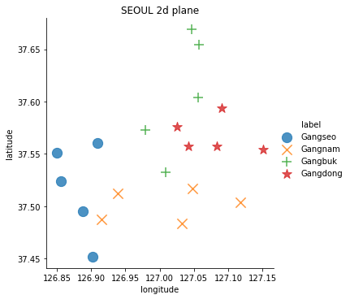

```python
import matplotlib.pyplot as plt
import seaborn as sns

# 경도, 위도 시각화
# X축, Y축, 데이터지정

sns.lmplot(x='longitude', y='latitude', data=train_df,
          fit_reg=False,   # 라인 출력 안함
          scatter_kws={'s':150}, # 좌표상의 점의 크기
          markers=['o', 'x', '+', '*'], # 점의 모양
          hue='label') # 범례(마커의 의미)

plt.title('SEOUL 2d plane')
```

## 데이터 전처리

#### 학습/테스트할 때 필요없는 속성을 제거 : 구 이름 & 동 이름

```python
train_df.drop(['district'], axis=1, inplace=True)
test_df.drop(['dong'], axis=1, inplace=True)

X_train = train_df[['longitude', 'latitude']]
Y_train = train_df[['label']]

X_test = test_df[['longitude', 'latitude']]
Y_test = test_df[['label']]
```

```python
train_df.drop(['district'], axis=1, inplace=True)
test_df.drop(['dong'], axis=1, inplace=True)

train_data = train_df[['longitude', 'latitude']]
test_data = train_df[['label']]

train_label = test_df[['longitude', 'latitude']]
test_label = test_df[['label']]
```

# 모델링

```python
from sklearn import tree
import numpy as np
import matplotlib.pyplot as plt
from sklearn import preprocessing
import warnings
warnings.filterwarnings(action='ignore')
```

- LabelEncoder() 함수를 통하여 레이블(문자)를 숫자로 변경
- One-Hot-Encoding 원 핫-인코딩 (예> 국어:0, 수학:1, 영어:2)

```python
le = preprocessing.LabelEncoder()
y_encoded = le.fit_transform(Y_train)

# random_state=35 는 반복실행시 동일한 데이터를 구성해라.
clf = tree.DecisionTreeClassifier(random_state=35).fit(X_train, y_encoded)
```

# 트리구조로 시각화

```python
def display_decision_surface(clf, X, y) :

    # X축과 Y축의 최소값 ~ 최대값 구간 설정
    x_min = X.longitude.min() - 0.01
    x_max = X.longitude.max() + 0.01
    y_min = X.latitude.min() - 0.01
    y_max = X.latitude.max() + 0.01

    n_classes = len(le.classes_)
    plot_colors = 'rywb'
    plot_step = 0.001

    xx, yy = np.meshgrid(np.arange(x_min, x_max, plot_step),
                        np.arange(y_min, y_max, plot_step))

    Z = clf.predict(np.c_[xx.ravel(), yy.ravel()])
    Z = Z.reshape(xx.shape)
    cs = plt.contourf(xx, yy, Z, cmap=plt.cm.RdYlBu)

    # 학습데이터 챠트에 표시
    for i, color in zip(range(n_classes), plot_colors):
        idx = np.where(y==i)
        plt.scatter(X.loc[idx].longitude,
                   X.loc[idx].latitude,
                   c=color,
                   label=le.classes_[i],
                   cmap=plt.cm.RdYlBu,
                    edgecolor='black',
                   s=200)

    # 챠트제목
    plt.title('Decision Tree 2D Plane', fontsize=18)

    # 챠트 기호 설명
    plt.legend(bbox_to_anchor=(1.05, 1),
              loc=2,
              borderaxespad=0.,
              fontsize=14)

    # x축, y축의 이름과 폰트 크기
    plt.xlabel('longitude', fontsize=16)
    plt.ylabel('latitude', fontsize=16)

    # 챠트크기
    plt.rcParams['figure.figsize'] = [7, 5]

    # 챠트폰트
    plt.rcParams['font.size'] = 14

    # 좌표상의 x 폰트, y 폰트
    plt.rcParams['xtick.labelsize'] = 14
    plt.rcParams['ytick.labelsize'] = 14

    # 챠트 출력
    plt.show()
```

함수 저장 기본 경로 C:\Users\TJ\AppData\Local\Programs\Python\Python38\Lib

# 작성된 함수를 동일한 이름으로 저장하여 호출할 수 있다.

from display_decision_surface import display_decision_surface

- 함수 테스트

display_decision_surface(clf, X_train, y_encoded)

## 의사결정 트리 옵션

1. max_depth : 트리의 최대 깊이
2. min_samples_split : 자식노드를 갖기 위한 최소 데이터 개수
3. min_samples_leaf : 마지막 노드의 최소데이터 개수
4. random_state : 동일한 결과 출력

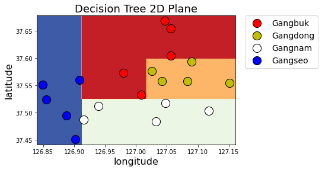

```python
clf = tree.DecisionTreeClassifier(max_depth=4,
                                 min_samples_split=2,
                                 min_samples_leaf=2,
                                 random_state=70).fit(X_train, y_encoded.ravel())

display_decision_surface(clf, X_train, y_encoded)
```

```python
import graphviz
dot_data = tree.export_graphviz(clf, out_file=None)
graph = graphviz.Source(dot_data)
graph.render("seoul")

dot_data = tree.export_graphviz(clf, out_file=None,
                         feature_names=['longitude','latitude'],
                         class_names=['Gangbuk', 'Gangdong', 'Gangnam', 'Gangseo'],
                         filled=True, rounded=True,
                         special_characters=True)
graph = graphviz.Source(dot_data)
graph
```

[figure not shown]

```python
weather = ['Sunny', 'Sunny', 'Overcat', 'Raniny', 'Raniny', 'Raniny',
          'Overcat', 'Sunny', 'Sunny', 'Raniny', 'Sunny', 'Overcat', 'Overcat', 'Raniny']

play = ['No', 'No', 'Yes', 'Yes', 'Yes', 'No', 'Yes', 'No', 'Yes', 'Yes', 'Yes', 'Yes', 'Yes', 'No']
```

- string을 int로 변환해주는 Feature Encoding 을 사용한다.

```python
from sklearn import preprocessing

le = preprocessing.LabelEncoder()

# 문자열을 숫자로 변환
weather_encoded = le.fit_transform(weather)

print(weather_encoded)
```

```
[2 2 0 1 1 1 0 2 2 1 2 0 0 1]
```

```python
weather = ['Sunny', 'Sunny', 'Overcat', 'Raniny', 'Raniny', 'Raniny',
          'Overcat', 'Sunny', 'Sunny', 'Raniny', 'Sunny', 'Overcat', 'Overcat', 'Raniny']

temp = ['Hot', 'Hot', 'Hot', 'Mild', 'Cool', 'Cool', 'Cool',
       'Mild', 'Cool', 'Mild', 'Mild', 'Mild', 'Hot', 'Mild']

play = ['No', 'No', 'Yes', 'Yes', 'Yes', 'No', 'Yes', 'No', 'Yes', 'Yes', 'Yes', 'Yes', 'Yes', 'No']
```

- string을 int로 변환해주는 Feature Encoding 을 사용한다.

```python
from sklearn import preprocessing

le = preprocessing.LabelEncoder()

# 문자열을 숫자로 변환
weather_encoded = le.fit_transform(weather)

print(weather_encoded)
```

```
[2 2 0 1 1 1 0 2 2 1 2 0 0 1]
```

```python
temp_encoded = le.fit_transform(temp)
print(temp_encoded)

play_encoded = le.fit_transform(play)
print(play_encoded)
```

```
[1 1 1 2 0 0 0 2 0 2 2 2 1 2]
[0 0 1 1 1 0 1 0 1 1 1 1 1 0]
```

- 날씨와 온도를 결합한다. --> 튜플로 묶는다

```python
features = zip(weather_encoded, temp_encoded)
features = list(features)
print(features)

# 한줄쓰기
# list(zip(weather_encoded, temp_encoded))
# tuple(zip(weather_encoded, temp_encoded))
```

```
[(2, 1), (2, 1), (0, 1), (1, 2), (1, 0), (1, 0), (0, 0), (2, 2), (2, 0), (1, 2), (2, 2), (0, 2), (0, 1), (1, 2)]
```

# 모델생성 -> 데이터 fitting -> 성능평가

```python
from sklearn.naive_bayes import GaussianNB

# 모델 객체 생성
model = GaussianNB()

# 학습
model.fit(features, play_encoded)

# 성능평가 : 예측
predicted = model.predict([[0, 2]]) # 0 : Overcat, 2 : Mild
print("예측결과 : ", predicted) # 0 : No, 1 : Yes
```

```
예측결과 :  [1]
```

```python
age = ['adult', 'teen', 'adult', 'teen', 'teen', 'adult','adult','adult','adult', 'teen']

beer = ['No', 'No', 'Yes', 'No', 'No', 'Yes', 'Yes', 'Yes', 'No', 'No']
```

```python
age_encoded = le.fit_transform(age)
print(age_encoded)

beer_encoded = le.fit_transform(beer)
print(beer_encoded)
```

```
[0 1 0 1 1 0 0 0 0 1]
[0 0 1 0 0 1 1 1 0 0]
```